# Clustering rush hours and delay/no delay

## Libraries

```python
import os
import pandas as pd
import seaborn as sn
import numpy as np
import sklearn as sk
import matplotlib as mpl
import seaborn as sns

from sklearn.model_selection import train_test_split
from matplotlib import pyplot as plt
from numpy import where
from collections import Counter
from scipy.cluster.hierarchy import dendrogram, linkage
from sklearn.cluster import AgglomerativeClustering
```

## 1. Cleaning the dataset - dummies

```python
# Importing the dataset with predefiled rush hours
df = pd.read_csv('January_Schiphol_Time_Groups.csv')
df.head()
```

|  | Unnamed: 0 | Station_Code | Station_Name | Train_Number | Train_Type | Train_Company | Train_Destination_Planned | Train_Destination_Actual | Train_Departure_Planned | Train_Departure_Actual | Train_Delay | MaxNumberOfStops | weekday | day_of_week | Train_Departure_Planned_Time | Time_Group |
| --- | --- | --- | --- | --- | --- | --- | --- | --- | --- | --- | --- | --- | --- | --- | --- | --- |
| 0 | 0 | HRL | Heerlen | 3528 | Intercity | NS | Schiphol Airport | Schiphol Airport | 2016-01-01 06:44:00 | 2016-01-01 06:44:00 | 0.0 | 10 | 4 | Friday | 64400 | Morning_Rush_Hour |
| 1 | 1 | EHV | Eindhoven | 3524 | Intercity | NS | Schiphol Airport | Schiphol Airport | 2016-01-01 06:48:00 | 2016-01-01 06:48:00 | 0.0 | 10 | 4 | Friday | 64800 | Morning_Rush_Hour |
| 2 | 2 | STD | Sittard | 3528 | Intercity | NS | Schiphol Airport | Schiphol Airport | 2016-01-01 07:00:00 | 2016-01-01 07:00:00 | 0.0 | 10 | 4 | Friday | 70000 | Morning_Rush_Hour |
| 3 | 3 | DV | Deventer | 1624 | Intercity | NS | Schiphol Airport | Schiphol Airport | 2016-01-01 07:02:00 | 2016-01-01 07:02:00 | 0.0 | 10 | 4 | Friday | 70200 | Morning_Rush_Hour |
| 4 | 4 | HT | 's-Hertogenbosch | 3524 | Intercity | NS | Schiphol Airport | Schiphol Airport | 2016-01-01 07:09:00 | 2016-01-01 07:09:00 | 0.0 | 10 | 4 | Friday | 70900 | Morning_Rush_Hour |

```python
df.columns
```

```
Index(['Unnamed: 0', 'Station_Code', 'Station_Name', 'Train_Number',
       'Train_Type', 'Train_Company', 'Train_Destination_Planned',
       'Train_Destination_Actual', 'Train_Departure_Planned',
       'Train_Departure_Actual', 'Train_Delay', 'MaxNumberOfStops', 'weekday',
       'day_of_week', 'Train_Departure_Planned_Time', 'Time_Group'],
      dtype='object')
```

```python
# The target variable
df['Time_Group'].unique()
```

```
array(['Morning_Rush_Hour', 'Between_Rush_hours', 'Afternoon_Rush_hour',
       'Night', 'Early_Morning'], dtype=object)
```

```python
#here i make dummies from the different station names so i can use it for the random forest and decision trees algerithms
StationDummies=pd.get_dummies(df['Station_Name'])
StationDummies
```

|  | 's-Hertogenbosch | Almelo | Almere Centrum | Amersfoort | Amersfoort Schothorst | Amsterdam Bijlmer ArenA | Amsterdam RAI | Amsterdam Zuid | Apeldoorn | Apeldoorn Osseveld | ... | Schiphol Airport | Sittard | Twello | Utrecht Centraal | Utrecht Overvecht | Veenendaal-De Klomp | Weert | Wierden | Wolfheze | Zaltbommel |
| --- | --- | --- | --- | --- | --- | --- | --- | --- | --- | --- | --- | --- | --- | --- | --- | --- | --- | --- | --- | --- | --- |
| 0 | 0 | 0 | 0 | 0 | 0 | 0 | 0 | 0 | 0 | 0 | ... | 0 | 0 | 0 | 0 | 0 | 0 | 0 | 0 | 0 | 0 |
| 1 | 0 | 0 | 0 | 0 | 0 | 0 | 0 | 0 | 0 | 0 | ... | 0 | 0 | 0 | 0 | 0 | 0 | 0 | 0 | 0 | 0 |
| 2 | 0 | 0 | 0 | 0 | 0 | 0 | 0 | 0 | 0 | 0 | ... | 0 | 1 | 0 | 0 | 0 | 0 | 0 | 0 | 0 | 0 |
| 3 | 0 | 0 | 0 | 0 | 0 | 0 | 0 | 0 | 0 | 0 | ... | 0 | 0 | 0 | 0 | 0 | 0 | 0 | 0 | 0 | 0 |
| 4 | 1 | 0 | 0 | 0 | 0 | 0 | 0 | 0 | 0 | 0 | ... | 0 | 0 | 0 | 0 | 0 | 0 | 0 | 0 | 0 | 0 |
| ... | ... | ... | ... | ... | ... | ... | ... | ... | ... | ... | ... | ... | ... | ... | ... | ... | ... | ... | ... | ... | ... |
| 76310 | 0 | 0 | 0 | 0 | 0 | 0 | 0 | 0 | 0 | 0 | ... | 0 | 0 | 0 | 0 | 0 | 0 | 0 | 0 | 0 | 0 |
| 76311 | 0 | 0 | 0 | 1 | 0 | 0 | 0 | 0 | 0 | 0 | ... | 0 | 0 | 0 | 0 | 0 | 0 | 0 | 0 | 0 | 0 |
| 76312 | 0 | 0 | 0 | 0 | 0 | 0 | 0 | 0 | 0 | 0 | ... | 0 | 0 | 0 | 0 | 0 | 0 | 0 | 0 | 0 | 0 |
| 76313 | 0 | 0 | 0 | 0 | 0 | 0 | 0 | 1 | 0 | 0 | ... | 0 | 0 | 0 | 0 | 0 | 0 | 0 | 0 | 0 | 0 |
| 76314 | 0 | 0 | 0 | 0 | 0 | 0 | 0 | 0 | 0 | 0 | ... | 0 | 0 | 0 | 0 | 0 | 0 | 0 | 0 | 0 | 0 |

76315 rows × 40 columns

```python
#i also do this for the days of the week
DayDummies=pd.get_dummies(df['day_of_week'])
DayDummies
```

|  | Friday | Monday | Saturday | Sunday | Thursday | Tuesday | Wednesday |
| --- | --- | --- | --- | --- | --- | --- | --- |
| 0 | 1 | 0 | 0 | 0 | 0 | 0 | 0 |
| 1 | 1 | 0 | 0 | 0 | 0 | 0 | 0 |
| 2 | 1 | 0 | 0 | 0 | 0 | 0 | 0 |
| 3 | 1 | 0 | 0 | 0 | 0 | 0 | 0 |
| 4 | 1 | 0 | 0 | 0 | 0 | 0 | 0 |
| ... | ... | ... | ... | ... | ... | ... | ... |
| 76310 | 0 | 0 | 0 | 1 | 0 | 0 | 0 |
| 76311 | 0 | 0 | 0 | 1 | 0 | 0 | 0 |
| 76312 | 0 | 0 | 0 | 1 | 0 | 0 | 0 |
| 76313 | 0 | 0 | 0 | 1 | 0 | 0 | 0 |
| 76314 | 0 | 0 | 0 | 1 | 0 | 0 | 0 |

76315 rows × 7 columns

```python
#for the time groups
TimeDummies=pd.get_dummies(df['Time_Group'])
TimeDummies
```

|  | Afternoon_Rush_hour | Between_Rush_hours | Early_Morning | Morning_Rush_Hour | Night |
| --- | --- | --- | --- | --- | --- |
| 0 | 0 | 0 | 0 | 1 | 0 |
| 1 | 0 | 0 | 0 | 1 | 0 |
| 2 | 0 | 0 | 0 | 1 | 0 |
| 3 | 0 | 0 | 0 | 1 | 0 |
| 4 | 0 | 0 | 0 | 1 | 0 |
| ... | ... | ... | ... | ... | ... |
| 76310 | 0 | 0 | 0 | 0 | 1 |
| 76311 | 0 | 0 | 0 | 0 | 1 |
| 76312 | 0 | 0 | 0 | 0 | 1 |
| 76313 | 0 | 0 | 0 | 0 | 1 |
| 76314 | 0 | 0 | 0 | 0 | 1 |

76315 rows × 5 columns

```python
# an also for the train types
TrainDummies=pd.get_dummies(df['Train_Type'])
TrainDummies
```

|  | Extra trein | Intercity | Sprinter |
| --- | --- | --- | --- |
| 0 | 0 | 1 | 0 |
| 1 | 0 | 1 | 0 |
| 2 | 0 | 1 | 0 |
| 3 | 0 | 1 | 0 |
| 4 | 0 | 1 | 0 |
| ... | ... | ... | ... |
| 76310 | 0 | 1 | 0 |
| 76311 | 0 | 1 | 0 |
| 76312 | 0 | 1 | 0 |
| 76313 | 0 | 1 | 0 |
| 76314 | 0 | 1 | 0 |

76315 rows × 3 columns

```python
#then i add all those dataframes with the dummies to the dataset
FinalDF=pd.concat([df, StationDummies, DayDummies, TimeDummies, TrainDummies], axis=1)
FinalDF
```

|  | Unnamed: 0 | Station_Code | Station_Name | Train_Number | Train_Type | Train_Company | Train_Destination_Planned | Train_Destination_Actual | Train_Departure_Planned | Train_Departure_Actual | ... | Tuesday | Wednesday | Afternoon_Rush_hour | Between_Rush_hours | Early_Morning | Morning_Rush_Hour | Night | Extra trein | Intercity | Sprinter |
| --- | --- | --- | --- | --- | --- | --- | --- | --- | --- | --- | --- | --- | --- | --- | --- | --- | --- | --- | --- | --- | --- |
| 0 | 0 | HRL | Heerlen | 3528 | Intercity | NS | Schiphol Airport | Schiphol Airport | 2016-01-01 06:44:00 | 2016-01-01 06:44:00 | ... | 0 | 0 | 0 | 0 | 0 | 1 | 0 | 0 | 1 | 0 |
| 1 | 1 | EHV | Eindhoven | 3524 | Intercity | NS | Schiphol Airport | Schiphol Airport | 2016-01-01 06:48:00 | 2016-01-01 06:48:00 | ... | 0 | 0 | 0 | 0 | 0 | 1 | 0 | 0 | 1 | 0 |
| 2 | 2 | STD | Sittard | 3528 | Intercity | NS | Schiphol Airport | Schiphol Airport | 2016-01-01 07:00:00 | 2016-01-01 07:00:00 | ... | 0 | 0 | 0 | 0 | 0 | 1 | 0 | 0 | 1 | 0 |
| 3 | 3 | DV | Deventer | 1624 | Intercity | NS | Schiphol Airport | Schiphol Airport | 2016-01-01 07:02:00 | 2016-01-01 07:02:00 | ... | 0 | 0 | 0 | 0 | 0 | 1 | 0 | 0 | 1 | 0 |
| 4 | 4 | HT | 's-Hertogenbosch | 3524 | Intercity | NS | Schiphol Airport | Schiphol Airport | 2016-01-01 07:09:00 | 2016-01-01 07:09:00 | ... | 0 | 0 | 0 | 0 | 0 | 1 | 0 | 0 | 1 | 0 |
| ... | ... | ... | ... | ... | ... | ... | ... | ... | ... | ... | ... | ... | ... | ... | ... | ... | ... | ... | ... | ... | ... |
| 76310 | 76310 | HVS | Hilversum | 1684 | Intercity | NS | Schiphol Airport | Schiphol Airport | 2016-01-31 22:53:00 | 2016-01-31 22:53:00 | ... | 0 | 0 | 0 | 0 | 0 | 0 | 1 | 0 | 1 | 0 |
| 76311 | 76311 | AMF | Amersfoort | 11686 | Intercity | NS | Schiphol Airport | Schiphol Airport | 2016-01-31 23:10:00 | 2016-01-31 23:10:00 | ... | 0 | 0 | 0 | 0 | 0 | 0 | 1 | 0 | 1 | 0 |
| 76312 | 76312 | DVD | Duivendrecht | 11686 | Intercity | NS | Schiphol Airport | Schiphol Airport | 2016-01-31 23:40:00 | 2016-01-31 23:40:00 | ... | 0 | 0 | 0 | 0 | 0 | 0 | 1 | 0 | 1 | 0 |
| 76313 | 76313 | ASDZ | Amsterdam Zuid | 11686 | Intercity | NS | Schiphol Airport | Schiphol Airport | 2016-01-31 23:46:00 | 2016-01-31 23:46:00 | ... | 0 | 0 | 0 | 0 | 0 | 0 | 1 | 0 | 1 | 0 |
| 76314 | 76314 | HVS | Hilversum | 11686 | Intercity | NS | Schiphol Airport | Schiphol Airport | 2016-01-31 23:23:00 | 2016-01-31 23:23:00 | ... | 0 | 0 | 0 | 0 | 0 | 0 | 1 | 0 | 1 | 0 |

76315 rows × 71 columns

```python
#here i add the column with 0 if the train didnt reach the destinationa dn 1 if it did reach the destination
FinalDF['ReachedEndDestination'] = np.where(FinalDF['Train_Destination_Planned']!=FinalDF['Train_Destination_Actual'], 0, 1).astype(int)
```

```python
# and then last but not least i add the group if there is a train delay
FinalDF['DelayOrNot'] = np.where(FinalDF['Train_Delay']<=60, 0, 1).astype(int)
FinalDF.info()
```

```
<class 'pandas.core.frame.DataFrame'>
RangeIndex: 76315 entries, 0 to 76314
Data columns (total 73 columns):
 #   Column                        Non-Null Count  Dtype
---  ------                        --------------  -----
 0   Unnamed: 0                    76315 non-null  int64
 1   Station_Code                  76315 non-null  object
 2   Station_Name                  76315 non-null  object
 3   Train_Number                  76315 non-null  int64
 4   Train_Type                    76315 non-null  object
 5   Train_Company                 76315 non-null  object
 6   Train_Destination_Planned     76315 non-null  object
 7   Train_Destination_Actual      76315 non-null  object
 8   Train_Departure_Planned       76315 non-null  object
 9   Train_Departure_Actual        76315 non-null  object
```

[output cut: 65 more lines]

```python
#here i put the delay and nodelay in seperated datasets
Delay=FinalDF[FinalDF['DelayOrNot']==1]
NoDelay=FinalDF[FinalDF['DelayOrNot']==0]
#then i count the amount of rows in that dataset
DelayCount=Delay.Station_Code.count()
NoDelayCount=NoDelay.Station_Code.count()

# Printing delays and no delays count
print(DelayCount)
print(NoDelayCount)
```

```
23244
53071
```

```python
# Sampling the dataset
NoDelay_Under=NoDelay.sample(DelayCount, random_state=42)
FinalDF_under=pd.concat([NoDelay_Under, Delay]).reset_index()
```

```python
# Mapping the rush hours to numbers, so that they are easy accessible within the models
FinalDF_under['Time_Group_Target'] = FinalDF_under['Time_Group'].map({"Morning_Rush_Hour":0,"Between_Rush_hours":1,'Afternoon_Rush_hour':2,"Early_Morning":3,"Night":4})
```

## Clustering rush hours

We want to predict 5 different rush hours using cluster modeling. AgglomerativeClustering will be used with both threshold and n clusters.

```python
# Plotting colums once more
FinalDF_under.columns
```

```
Index(['index', 'Unnamed: 0', 'Station_Code', 'Station_Name', 'Train_Number',
       'Train_Type', 'Train_Company', 'Train_Destination_Planned',
       'Train_Destination_Actual', 'Train_Departure_Planned',
       'Train_Departure_Actual', 'Train_Delay', 'MaxNumberOfStops', 'weekday',
       'day_of_week', 'Train_Departure_Planned_Time', 'Time_Group',
       ''s-Hertogenbosch', 'Almelo', 'Almere Centrum', 'Amersfoort',
       'Amersfoort Schothorst', 'Amsterdam Bijlmer ArenA', 'Amsterdam RAI',
       'Amsterdam Zuid', 'Apeldoorn', 'Apeldoorn Osseveld', 'Arnhem',
       'Deventer', 'Driebergen-Zeist', 'Duivendrecht', 'Ede-Wageningen',
       'Eindhoven', 'Enschede', 'Enschede Kennispark', 'Geldermalsen',
       'Heerlen', 'Hengelo', 'Hilversum', 'Hilversum Sportpark',
       'Hollandsche Rading', 'Lelystad Centrum', 'Naarden-Bussum', 'Nijmegen',
       'Oosterbeek', 'Roermond', 'Rotterdam Centraal', 'Schiphol Airport',
       'Sittard', 'Twello', 'Utrecht Centraal', 'Utrecht Overvecht',
       'Veenendaal-De Klomp', 'Weert', 'Wierden', 'Wolfheze', 'Zaltbommel',
       'Friday', 'Monday', 'Saturday', 'Sunday', 'Thursday', 'Tuesday',
       'Wednesday', 'Afternoon_Rush_hour', 'Between_Rush_hours',
       'Early_Morning', 'Morning_Rush_Hour', 'Night', 'Extra trein',
       'Intercity', 'Sprinter', 'ReachedEndDestination', 'DelayOrNot'],
      dtype='object')
```

```python
# Printing the features that will be inserted into the model
FinalDF_under.iloc[:, [11,12,18,19,20,21,22,23,24,25,26,27,28,29,30,31,32,33,34,35,36,37,38,39,40,41,42,43,44,45,46,47,48,49,50,51,52,53,54,55,56,57,58,59,60,61,62,63,69,70,71,72]]
```

|  | Train_Delay | MaxNumberOfStops | Almelo | Almere Centrum | Amersfoort | Amersfoort Schothorst | Amsterdam Bijlmer ArenA | Amsterdam RAI | Amsterdam Zuid | Apeldoorn | ... | Monday | Saturday | Sunday | Thursday | Tuesday | Wednesday | Extra trein | Intercity | Sprinter | ReachedEndDestination |
| --- | --- | --- | --- | --- | --- | --- | --- | --- | --- | --- | --- | --- | --- | --- | --- | --- | --- | --- | --- | --- | --- |
| 0 | 0.0 | 8 | 0 | 0 | 0 | 0 | 1 | 0 | 0 | 0 | ... | 0 | 1 | 0 | 0 | 0 | 0 | 0 | 1 | 0 | 1 |
| 1 | 11.0 | 6 | 0 | 0 | 0 | 0 | 0 | 0 | 1 | 0 | ... | 0 | 0 | 0 | 0 | 0 | 1 | 0 | 1 | 0 | 1 |
| 2 | 0.0 | 8 | 0 | 0 | 0 | 0 | 0 | 0 | 0 | 0 | ... | 0 | 0 | 0 | 0 | 1 | 0 | 0 | 1 | 0 | 1 |
| 3 | 0.0 | 11 | 0 | 0 | 0 | 0 | 0 | 0 | 0 | 0 | ... | 0 | 0 | 0 | 1 | 0 | 0 | 0 | 1 | 0 | 1 |
| 4 | 0.0 | 7 | 0 | 0 | 0 | 0 | 0 | 0 | 0 | 0 | ... | 0 | 1 | 0 | 0 | 0 | 0 | 0 | 1 | 0 | 1 |
| ... | ... | ... | ... | ... | ... | ... | ... | ... | ... | ... | ... | ... | ... | ... | ... | ... | ... | ... | ... | ... | ... |
| 46483 | 107.0 | 6 | 0 | 0 | 0 | 0 | 0 | 0 | 0 | 0 | ... | 0 | 0 | 1 | 0 | 0 | 0 | 0 | 1 | 0 | 1 |
| 46484 | 94.0 | 4 | 0 | 0 | 0 | 0 | 0 | 0 | 0 | 0 | ... | 0 | 0 | 1 | 0 | 0 | 0 | 0 | 1 | 0 | 1 |
| 46485 | 94.0 | 4 | 0 | 0 | 0 | 0 | 0 | 0 | 0 | 0 | ... | 0 | 0 | 1 | 0 | 0 | 0 | 0 | 1 | 0 | 1 |
| 46486 | 108.0 | 4 | 0 | 0 | 0 | 0 | 0 | 0 | 1 | 0 | ... | 0 | 0 | 1 | 0 | 0 | 0 | 0 | 1 | 0 | 1 |
| 46487 | 130.0 | 4 | 0 | 0 | 0 | 0 | 1 | 0 | 0 | 0 | ... | 0 | 0 | 1 | 0 | 0 | 0 | 0 | 1 | 0 | 1 |

46488 rows × 52 columns

```python
x = FinalDF_under.iloc[:, [11,12,17,18,19,20,21,22,23,24,25,26,27,28,29,30,31,32,33,34,35,36,37,38,39,40,41,42,43,44,45,46,47,48,49,50,51,52,53,54,55,56,57,58,59,60,61,62,63,69,70,71,72]]
y = FinalDF_under['Time_Group_Target']
# 15
```

```python
# Define number of clusters by setting distance threshold
agglom = AgglomerativeClustering(distance_threshold=120, n_clusters=None)

# Use this line for agglomerative clustering using normalized data
agglom.fit(x)
```

```
AgglomerativeClustering(distance_threshold=120, n_clusters=None)
```

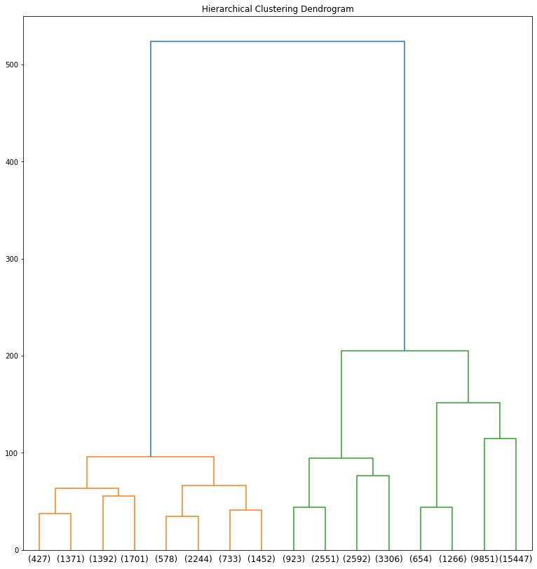

```python
def plot_dendrogram(model, **kwargs):
    # create the counts of samples under each node
    counts = np.zeros(model.children_.shape[0])
    n_samples = len(model.labels_)
    for i, merge in enumerate(model.children_):
        current_count = 0
        for child_idx in merge:
            if child_idx < n_samples:
                current_count += 1  # leaf node
            else:
                current_count += counts[child_idx - n_samples]
        counts[i] = current_count

    linkage_matrix = np.column_stack([model.children_, model.distances_,
                                      counts]).astype(float)

    # Plot the corresponding dendrogram
    dendrogram(linkage_matrix, **kwargs)

plt.figure(figsize=(13,14))
plt.title('Hierarchical Clustering Dendrogram')
# plot the top three levels of the dendrogram
plot_dendrogram(agglom, truncate_mode='level', p=3)
plt.show()
```

```python
# Define number of clusters by setting distance threshold
agglom = AgglomerativeClustering(distance_threshold=None, n_clusters=5)

# Use this line for agglomerative clustering using normalized data
agglom.fit(x)
```

```
AgglomerativeClustering(n_clusters=5)
```

```python
# Amount of clusters
# +1 because it starts from 0
print('Found clusters count: {}'.format(agglom.labels_.max() + 1))
```

```
Found clusters count: 5
```

```python
# Assigning the dataset to another dataset, that will hold the clustered rush hours
df2 = FinalDF_under
df2['Cluster'] = agglom.labels_

# and printing it
df2
```

[output not shown]

46488 rows × 77 columns

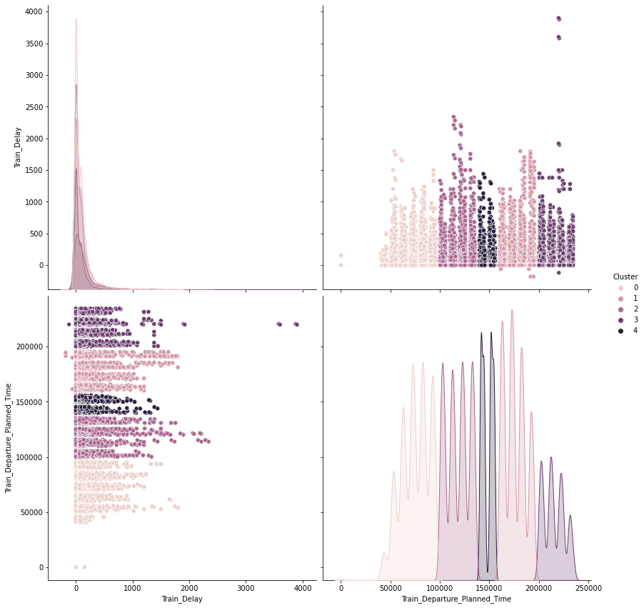

```python
# Showing the relation between train delay and the planned departured time
ax = sns.pairplot(df2[['Train_Delay','Train_Departure_Planned_Time','Cluster']], hue="Cluster", height=6, aspect=1)
plt.show()
```

We can see that the firt cluster starts from 12am and ends at 10am, the second one ends at 14pm, the third cluster is quite short from 14pm to 16pm, then the cluster four is until 20pm. The last cluster ends at 11:59pm. The time between them is not balanced for every hour, but we see the clusters got more accurate time slots than the one we found during research.

Let's plot it in a more beautiful way.

[figure not shown]

```python
# Creating a figure
plt.figure(figsize=(10, 7))
# Creating a scatter plot with the train delay and the planned departure time. The colors are the different clusters (rush hours)
scatter = plt.scatter(x['Train_Delay'], x['Train_Departure_Planned_Time'], c=agglom.labels_, cmap='rainbow')

# Creating the handles for the legend
handles, labels = scatter.legend_elements(prop="colors", alpha=0.9)
# Adding legend
plt.legend(handles, ["Morning Rush Hour","Between Rush Hour", "Afternoon Rush Hour","Early Morning","Night"], loc="upper right", title="Rush Hours")
# Adding labels and title
plt.xlabel("Train Delay")
plt.ylabel("Planned Departure Time")
plt.title("Rush hours found by clustering")
```

These are the rush hours found by the cluster model.

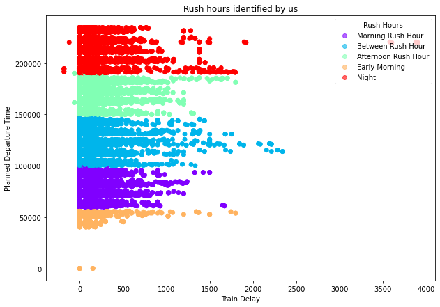

```python
plt.figure(figsize=(10, 7))
# Creating a scatter plot with the train delay and the planned departure time. The colors are the different rush hours, identified by us
scatter = plt.scatter(x['Train_Delay'], x['Train_Departure_Planned_Time'], c=y, cmap='rainbow')

# Creating handles for the legend
handles, labels = scatter.legend_elements(prop="colors", alpha=0.6)
# Adding legend
plt.legend(handles, ["Morning Rush Hour","Between Rush Hour", "Afternoon Rush Hour","Early Morning","Night"], loc="upper right", title="Rush Hours")
# Adding labels + title
plt.xlabel("Train Delay")
plt.ylabel("Planned Departure Time")
plt.title("Rush hours identified by us")
```

Rush hours identified by us.

## Clustering delay or no delay

In this step we will try to predict if there is delay or not using agglomerative clustering.

```python
# Creating x and y for predicting if there's delay or not
x = FinalDF_under.iloc[:, [12,57,58,59,60,61,62,63,64,65,66,67,68,69,70,71,72]]
y = FinalDF_under['DelayOrNot']

x_train, x_test, y_train, y_test = train_test_split(x,y,test_size=0.20, random_state=0)
```

```python
# showing the features in x
x.head()
```

|  | MaxNumberOfStops | Friday | Monday | Saturday | Sunday | Thursday | Tuesday | Wednesday | Afternoon_Rush_hour | Between_Rush_hours | Early_Morning | Morning_Rush_Hour | Night | Extra trein | Intercity | Sprinter | ReachedEndDestination |
| --- | --- | --- | --- | --- | --- | --- | --- | --- | --- | --- | --- | --- | --- | --- | --- | --- | --- |
| 0 | 8 | 0 | 0 | 1 | 0 | 0 | 0 | 0 | 0 | 0 | 0 | 1 | 0 | 0 | 1 | 0 | 1 |
| 1 | 6 | 0 | 0 | 0 | 0 | 0 | 0 | 1 | 0 | 1 | 0 | 0 | 0 | 0 | 1 | 0 | 1 |
| 2 | 8 | 0 | 0 | 0 | 0 | 0 | 1 | 0 | 0 | 0 | 0 | 1 | 0 | 0 | 1 | 0 | 1 |
| 3 | 11 | 0 | 0 | 0 | 0 | 1 | 0 | 0 | 1 | 0 | 0 | 0 | 0 | 0 | 1 | 0 | 1 |
| 4 | 7 | 0 | 0 | 1 | 0 | 0 | 0 | 0 | 1 | 0 | 0 | 0 | 0 | 0 | 1 | 0 | 1 |

```python
# Define number of clusters by setting distance threshold
agglom = AgglomerativeClustering(distance_threshold=None, n_clusters=2)

# Use this line for agglomerative clustering using normalized data
agglom.fit(x)
```

```
AgglomerativeClustering()
```

```python
# Amount of clusters
# +1 because it starts from 0
print('Found clusters count: {}'.format(agglom.labels_.max() + 1))
```

```
Found clusters count: 2
```

```python
# Again creating a dataset that will hold the clustered delay or not variable
df2 = FinalDF_under
df2['Clustered DelayOrNot'] = agglom.labels_

df2.head()
```

|  | index | Unnamed: 0 | Station_Code | Station_Name | Train_Number | Train_Type | Train_Company | Train_Destination_Planned | Train_Destination_Actual | Train_Departure_Planned | ... | Morning_Rush_Hour | Night | Extra trein | Intercity | Sprinter | ReachedEndDestination | DelayOrNot | Time_Group_Target | Clustered DelayOrNot | Cluster |
| --- | --- | --- | --- | --- | --- | --- | --- | --- | --- | --- | --- | --- | --- | --- | --- | --- | --- | --- | --- | --- | --- |
| 0 | 38012 | 38012 | ASB | Amsterdam Bijlmer ArenA | 3130 | Intercity | NS | Schiphol Airport | Schiphol Airport | 2016-01-16 09:46:00 | ... | 1 | 0 | 0 | 1 | 0 | 1 | 0 | 0 | 0 | 2 |
| 1 | 48351 | 48351 | ASDZ | Amsterdam Zuid | 11634 | Intercity | NS | Schiphol Airport | Schiphol Airport | 2016-01-20 10:46:00 | ... | 0 | 0 | 0 | 1 | 0 | 1 | 0 | 1 | 1 | 1 |
| 2 | 61875 | 61875 | ED | Ede-Wageningen | 3122 | Intercity | NS | Schiphol Airport | Schiphol Airport | 2016-01-26 06:56:00 | ... | 1 | 0 | 0 | 1 | 0 | 1 | 0 | 0 | 0 | 2 |
| 3 | 15659 | 15659 | STD | Sittard | 3572 | Intercity | NS | Schiphol Airport | Schiphol Airport | 2016-01-07 18:00:00 | ... | 0 | 0 | 0 | 1 | 0 | 1 | 0 | 2 | 0 | 0 |
| 4 | 3571 | 3571 | HVS | Hilversum | 11658 | Intercity | NS | Schiphol Airport | Schiphol Airport | 2016-01-02 16:23:00 | ... | 0 | 0 | 0 | 1 | 0 | 1 | 0 | 2 | 1 | 1 |

5 rows × 77 columns

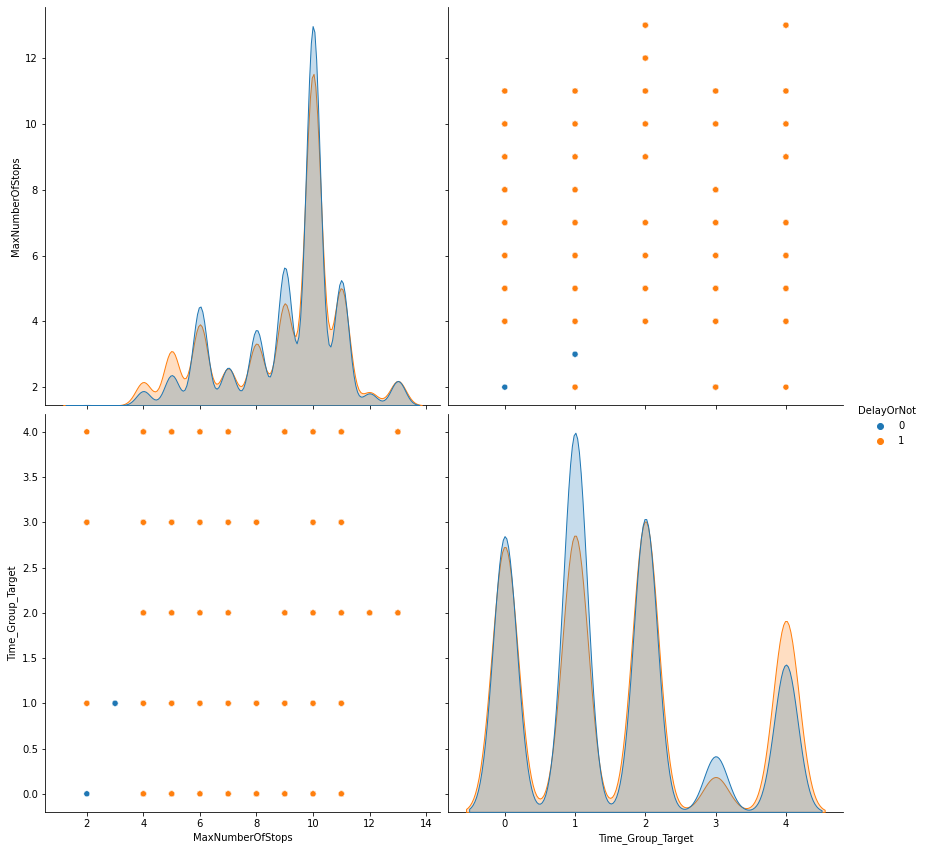

```python
ax = sns.pairplot(df2[['MaxNumberOfStops','Time_Group_Target','DelayOrNot']], hue="DelayOrNot", height=6, aspect=1)
plt.show()
```

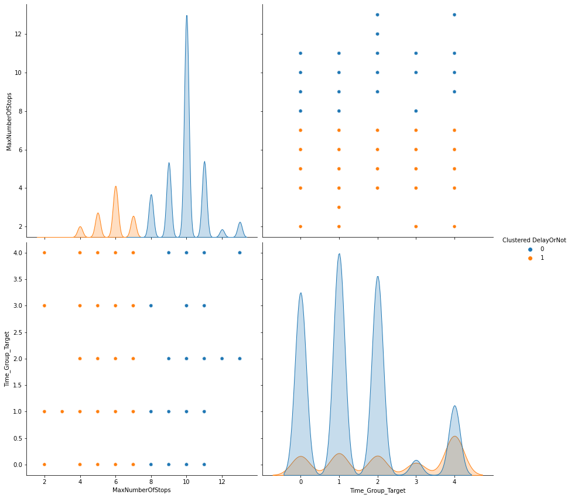

```python
ax = sns.pairplot(df2[['MaxNumberOfStops','Time_Group_Target','Clustered DelayOrNot']], hue="Clustered DelayOrNot", height=6, aspect=1)
plt.show()
```

Let's validate our results.

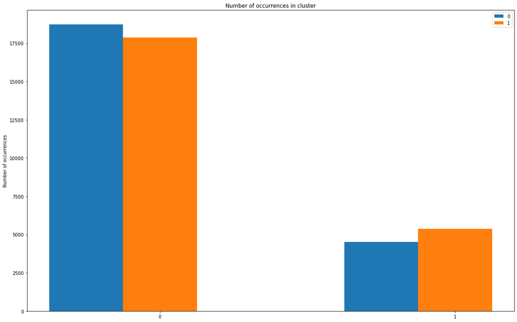

```python
# Define labels for species
actual = df2['DelayOrNot'].unique()

# Define labels for clusters
clusters = df2['Clustered DelayOrNot'].unique()

# Sort cluster names in alphabetical order, i.e.,
# Cluster 0, Cluster 1, Cluster 2, etc.
clusters.sort()

# Determine the location for cluster labels
x_c = np.arange(len(clusters))

# Define the width of the bars
width = 0.25

# Create the bar plot
fig, ax = plt.subplots(figsize=(16,10))
offset = -width
for spec in actual:
    nr_occurrences = []
    for clus in clusters:
        nr = df2[(df2['Clustered DelayOrNot']==clus) & (df2['DelayOrNot'] == spec)]['Clustered DelayOrNot'].count()
        nr_occurrences.append(nr)
    rects = ax.bar(x_c + offset, nr_occurrences, width, label=spec)
    offset = offset + width

# Add text for labels, title and custom x-axis tick labels, etc.
ax.set_ylabel('Number of occurrences')
ax.set_title('Number of occurrences in cluster')
ax.set_xticks(x_c)
ax.set_xticklabels(clusters)
ax.legend()

fig.tight_layout()
plt.show()
```

```python
print(len(df2['DelayOrNot'][df2['DelayOrNot'] == 1]))
print(len(df2['DelayOrNot'][df2['DelayOrNot'] == 0]))
```

```
23244
23244
```

```python
print(len(df2['Clustered DelayOrNot'][df2['Clustered DelayOrNot'] == 1]))
print(len(df2['Clustered DelayOrNot'][df2['Clustered DelayOrNot'] == 0]))
```

```
9898
36590
```

Based on the plot we can see the two clusters and how the actual data was distributed between them. The 0 (blue bar) shows no delay and 1 (orange bar) shows delay. In the first cluster 0, we see that most of the train departures had no delay with count of above 17000, but there were also departures with delays that were almost the same amount. The results in the second cluster are the same, with the difference that the amount is much less with around 5000. But again the delay and no delay departures are mixed and it is not clear if this cluster holds only delays or no delays.

## Conclusion

The cluster model is useful when we use it to predict the rush hours, based on the features we have. We found quite different rush hours using Agglomerative Clustering that fit better with the data, compared with the rush hours we identified.

About predicting if there is delay or not, the algorithm did not perform well and we can not say which cluster holds delays or no delays.